# Introduction

Baltimore’s Trash Wheel project represents an innovative and vital environmental initiative aimed at tackling urban water pollution. Launched in 2014 by the Waterfront Partnership of Baltimore with support from the Maryland Port Administration, the project uses solar and hydro-powered devices known as Trash Wheels to intercept and remove trash from rivers and streams before it can reach the Chesapeake Bay. To date, these devices have collected over one million pounds of debris, including plastic bottles, polystyrene containers, and cigarette butts, which are notorious for harming aquatic life and polluting urban waters.

The dataset, `trashwheel.csv`, chronicles the daily operations of these Trash Wheels. It meticulously records the volume and weight of trash collected, categorized by type and indexed by date, across multiple locations in Baltimore. This data not only underscores the operational success of the Trash Wheels but also highlights seasonal and event-driven fluctuations in urban waste generation and collection.

## Importance of the Dataset

This dataset is crucial for several reasons:

- **Environmental Impact**: It provides empirical evidence of the quantity and types of urban waste that can be intercepted from urban waterways, offering insights into the effectiveness of innovative pollution control technologies.
- **Policy and Planning**: By analyzing trends and patterns in the data, policymakers and urban planners can better understand the sources and scales of water pollution, leading to more targeted and effective environmental regulations and initiatives.
- **Public Awareness and Education**: Disseminating findings from this data can enhance public awareness about the impact of littering and the benefits of recycling, potentially fostering more environmentally responsible behaviors.

## Questions and our approach

1. What are the types of waste composition that has their weight/volume increase in the last 6 months?
- **Introduction:** This report examines the composition of waste collected over the last six months, focusing on specific categories: Plastic Bottles, Polystyrene, Cigarette Butts, Glass Bottles, Plastic Bags, Wrappers, and Sports Balls. The goal is to determine which types of waste have seen increases in the collected amount. Understanding these trends is vital for waste management agencies to refine their operations and for policymakers to gauge the effectiveness of current environmental regulations and the impact of societal behavior on waste production. This inquiry is driven by the urgent need for environmental sustainability solutions in the face of growing urban populations, which typically result in higher waste generation.
- **Approach:** We used several plots and methods for this question.
  - **Bar Chart:** This chart provides an immediate visual comparison of the total waste collected by type over the last six months. To accommodate the wide range of values, we applied a logarithmic scale, improving visibility for categories with smaller volumes.

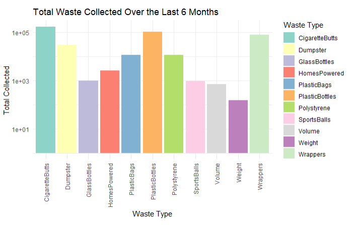

  - **Line and Scatter Plots:** Although the bar chart showed the volume for each waste type, it lacked temporal details necessary for trend analysis. Initially, a line chart was used, but it was cluttered due to the diversity of waste types. We opted for a scatter plot with linear regression to clarify the trends over time.

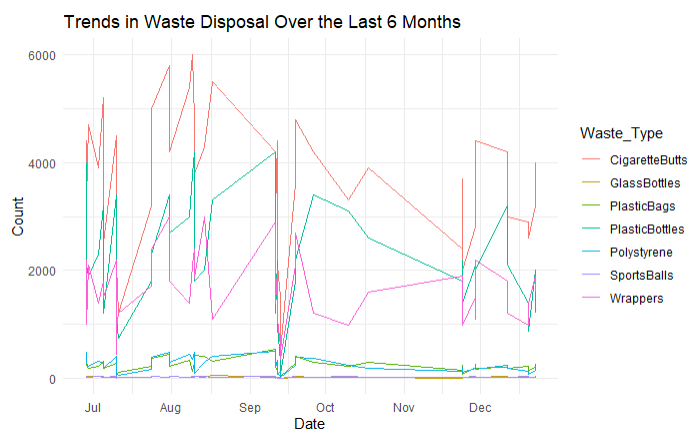

  - A box plot was also implemented, however, we can see directly from the visualization that the outliers was not actually accounted for a large part in the dataset. Instead, there was only 1 outlier found in the plastic bags category. This could happen from several possible reasons and a wrong labeling process could be one of them. Therefore, we trying to approach the problem with another visualization that exclude the outlier and give a better looks such as the multi-faceted bar chart focusing on the dominant waste type.

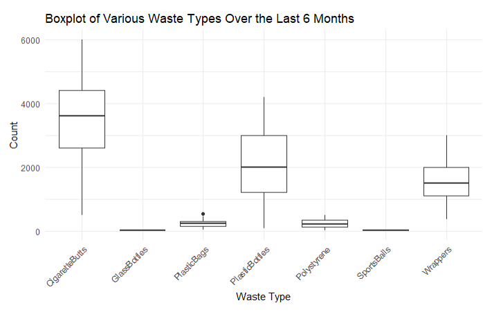

    boxplot

- **Analysis:**

```{r} library(dplyr) library(lubridate) library(ggplot2) library(tidyr)

# Read the CSV file

data <- read.csv(“trashwheel.csv”) data$Date <- as.Date(data$Date, format = “%m/%d/%Y”)

#filter data for the last 6 months recent_data <- data %>% filter(Date > max(Date) %m-% months(6))

#calculate total number of encountered waste for each category by summing the column. sums_recent <- recent_data %>% select(-Year) %>% select(-Date) %>% summarise(across(where(is.numeric), sum, na.rm = TRUE))

#format sums_recent <- pivot_longer(sums_recent, cols = everything(), names_to = “Waste_Type”, values_to = “Total”)

````
```{r}
#bar chart
ggplot(sums_recent, aes(x = Waste_Type, y = Total, fill = Waste_Type)) +
  geom_bar(stat = "identity") +
  scale_y_log10() +
  theme_minimal() +
  theme(axis.text.x = element_text(angle = 90, vjust = 0.5, hjust=1)) +
  labs(title = "Total Waste Collected Over the Last 6 Months",
       x = "Waste Type",
       y = "Total Collected",
       fill = "Waste Type") +
  scale_fill_brewer(palette = "Set3")
````

```{r} #get the number of collected waste for each type in a day for the simple linear regression recent_data_long <- recent_data %>% select(Date, PlasticBottles, Polystyrene, CigaretteButts, GlassBottles, PlasticBags, Wrappers, SportsBalls) %>% gather(key = “Waste_Type”, value = “Count”, -Date)

recent_data_long$Date_numeric <- as.numeric(recent_data_long$Date - min(recent_data_long$Date))

# List of waste types to model

waste_types <- c(“Polystyrene”, “CigaretteButts”, “GlassBottles”, “PlasticBags”, “Wrappers”, “SportsBalls”)

# Initialize an empty list to store models

models <- list()

# Loop over waste types, fit model, and store

for(waste in waste_types) { model <- lm(Count ~ Date_numeric, data = filter(recent_data_long, Waste_Type == waste)) models[[waste]] <- model }

# Display summaries of all models

lapply(models, summary)

# Function to create prediction plots for a given waste type

create_prediction_plot <- function(waste) { # Extending the prediction range to include the next 3 months max_date_numeric <- max(recent_data_long$Date_numeric) future_extend <- as.numeric((max(recent_data_long$Date) %m+% months(3)) - max(recent_data_long$Date)) prediction_data <- data.frame(Date_numeric = seq(min(recent_data_long$Date_numeric), max_date_numeric + future_extend, by = 1)) prediction_data$Predicted_Count <- predict(models[[waste]], newdata = prediction_data) prediction_data$Date <- min(recent_data_long$Date) + prediction_data$Date_numeric * days(1)

# Plotting p <- ggplot(filter(recent_data_long, Waste_Type == waste), aes(x = Date, y = Count)) + geom_point(aes(color = “Actual Data”), size = 2) + geom_line(data = prediction_data, aes(x = Date, y = Predicted_Count, color = “Predicted Data”)) + theme_minimal() + labs(title = paste(“Predictive Model for”, waste, “Waste”), x = “Date”, y = paste(“Count of”, waste), color = “Data Type”)

return(p) }

# Use the function to create plots

plot_list <- lapply(waste_types, create_prediction_plot) plot_list[[1]] plot_list[[2]] plot_list[[3]] plot_list[[4]] plot_list[[5]] plot_list[[6]]

[output not shown]

[figure not shown]

Multifacetedbar

- **Discussion:** The regression analysis of scatter plots revealed divergent trends in waste generation, highlighting both positive environmental progress and areas needing improvement. The variability in trends across categories reflects the complex factors influencing waste generation, from regulatory changes to seasonal behaviors. These insights are crucial for shaping effective waste management strategies and promoting sustainable community practices.

  Moreover, the multi-faceted bar chart provide a deeper understanding of waste prevalence and variation in collection figures. This data can guide waste management and recycling initiatives to focus on areas with high waste production or significant collection variability, such as launching public awareness campaigns for proper disposal practices or enhancing recycling efforts.

2. Which type of trash wheels have a highest performance, throughout the years, analyse the improvement of the usage of different trash wheel?

- **Introduction:** The analysis scrutinizes the efficiency of trash wheels over the years, focusing on the annual total weight and volume of collected waste. It highlights significant variations in performance among different trash wheels, with notable improvements observed. The Gwynnda Trash Wheel, in particular, demonstrates a marked increase in waste collection efficiency. Graphical representations of yearly performance growth rates reveal trends in operational effectiveness. This report underscores the pivotal role of trash wheels in environmental management, showcasing their evolving impact on waste collection and the necessity for continuous technological advancements to enhance their efficacy in pollution reduction and resource conservation.
- **Approach:** We used several plots and methods for this question.
  - First, to delve deeper into the analysis of waste collection efficiency and effectiveness, we calculate the total weight and volume of waste collected within a year. This step is crucial for understanding the scale of waste management efforts and their year-on-year progression.
    - We have created 2 new variables, which are `TotalWeight` and `TotalVolume` calculated by taking sum of weight and volume within a year for each Trash Wheel, and `Uses` calculated by number of uses for each Trash Wheel over Years.

  `{r} # Data segmentation by Trash Wheel by Year trashwheel_segments <- trashwheel_data %>% group_by(Name, Year) %>% summarise( Uses = n(), AverageWeight = mean(Weight, na.rm = TRUE), AverageVolume = mean(Volume, na.rm = TRUE), TotalWeight = sum(Weight, na.rm = TRUE), TotalVolume = sum(Volume, na.rm = TRUE) ) trashwheel_segments`
  - now we plot the line graph to visualize the performance in terms of `TotalWeight` and `TotalVolume` of trash wheel over years

  ```{r} # Time-Series Analysis: Performance of each Trash Wheel over time ggplot(trashwheel_segments, aes(x = Year, y = TotalWeight, group = Name, color = Name)) + geom_line() + geom_point(size = 3, shape = 21, fill = “white”) + # Using filled points for better visibility theme_minimal() + labs(title = “Annual Total Weight of Collected Waste by Trash Wheel”, x = “Year”, y = “Total Weight (Tons)”) + theme(legend.title = element_blank(), # Removing the legend title for clarity legend.position = “bottom”, # Positioning legend at the bottom for easy comparison axis.text.x = element_text(angle = 45, hjust = 1))

  ggplot(trashwheel_segments, aes(x = Year, y = TotalVolume, group = Name, color = Name)) + geom_line() + geom_point(size = 3, shape = 21, fill = “white”) + # Using filled points for better visibility theme_minimal() + labs(title = “Annual Total Volume of Collected Waste by Trash Wheel”, x = “Year”, y = “Total Volume (Cubic Yards)”) + theme(legend.title = element_blank(), # Removing the legend title for clarity legend.position = “bottom”, # Positioning legend at the bottom for easy comparison axis.text.x = element_text(angle = 45, hjust = 1)) ```

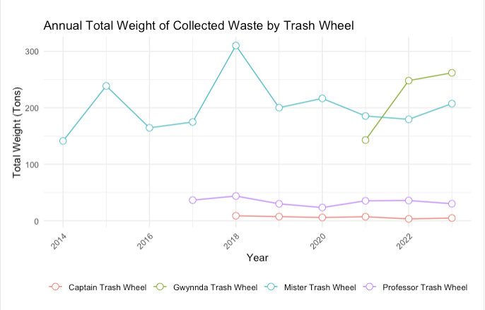

  Annual Total Weight of Collected Waste by Trash Wheel

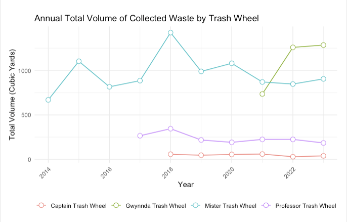

  Annual Total Volume of Collected Wasted by Trash Wheel

`{r} # Calculating Yearly Performance Growth Rate trashwheel_segments <- trashwheel_segments %>% group_by(Name) %>% arrange(Year) %>% mutate( WeightGrowthRate = (TotalWeight / lag(TotalWeight) - 1) * 100, # Growth weight rate VolumeGrowthRate = (TotalVolume / lag(TotalVolume) - 1) * 100 # Growth volume rate ) %>% replace_na(list(WeightGrowthRate = 0, VolumeGrowthRate = 0)) %>% # means that at the time when a trash wheel start to be used, we set the intial value for the rate equals to 0. arrange(desc(WeightGrowthRate), desc(VolumeGrowthRate)) trashwheel_segments`

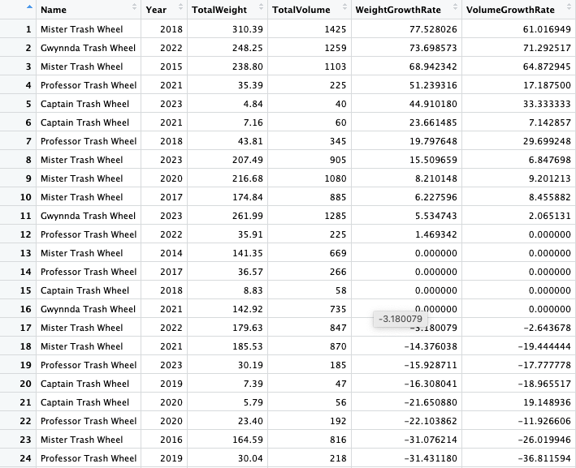

Growth Rate in Weight and Volume of Trash Wheel

```{r} library(ggplot2) library(dplyr) library(ggrepel)

# Assigning unique shapes to each Trash Wheel

shapes <- c(16, 17, 18, 19) # Circle, Triangle, Square, Diamond

ggplot(trashwheel_segments, aes(x = WeightGrowthRate, y = VolumeGrowthRate, color = Name)) + geom_point(aes(shape = Name), size = 3) + geom_smooth(method = “lm”, se = FALSE) + geom_text_repel(aes(label = if_else(Year == max(Year) | Year == min(Year), as.character(Year), ““)), nudge_y = 0.05, size = 3, segment.color = ‘grey50’) + # Add labels to first and last years for clarity scale_shape_manual(values = shapes) + # Apply the shapes theme_minimal() + labs(title =”Relationship Between Weight and Volume Growth Rates by Trash Wheel”, x = “Weight Growth Rate (%)”, y = “Volume Growth Rate (%)”) + theme(legend.title = element_blank())

[output not shown]

[figure not shown]

Volume Growth Rate

[figure not shown]

Weight Growth Rate

`{r} ggplot(composition_data_long, aes(x = Name, y = Quantity, fill = TrashType)) + geom_bar(stat = "identity", position = "stack") + theme_minimal() + theme( axis.text.x = element_text(angle = 45, hjust = 1), legend.position = "bottom" ) + labs(title = paste("Composition of Trash Collected in", latest_year), x = "Trash Wheel", y = "Total Weight Collected") + scale_fill_brewer(palette = "Spectral") + scale_y_continuous(labels = scales::comma_format(scale = 1e-3))`

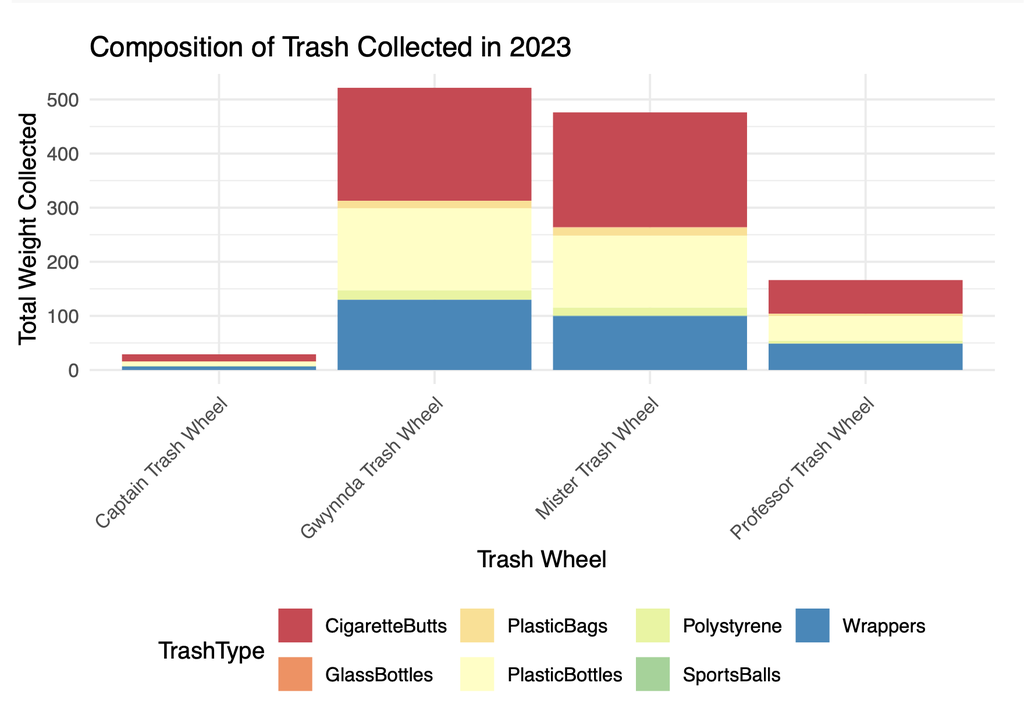

Composition of Trash Collected in 2023

- **Analysis:**
  - The bar chart depicts the sorts of trash collected by each trash wheel. The Gwynnda and Mister Trash Wheels collect substantially more total rubbish than the Captain and Professor Trash Wheels, both in terms of diversity and volume.
  - Cigarette butts appear to be the most commonly collected item across all trash wheels, as demonstrated by the dominating red section, although plastic bottles also account for a significant fraction of the debris, particularly for Gwynnda and Mister Trash Wheels.
  - This graph highlights the varying efficacy of different garbage wheels and implies a concentration on specific waste categories, potentially owing to their location or wheel design.
  - However, we believe that there is not enough evidence to conclude which type of trash wheel has a highest performance. Indeed, we decided to analyze the number of use for each trash wheel over the years.

```{r} library(ggplot2)

min_uses <- min(trashwheel_segments$Uses) - 10 max_uses <- max(trashwheel_segments$Uses) + 10

# Plotting with extended regression lines

ggplot(trashwheel_segments, aes(x = Uses, y = TotalWeight, label = Name)) + geom_point(aes(color = Name), size = 4) + geom_smooth(aes(color = Name), method = “lm”, se = FALSE, fullrange = TRUE) + scale_x_continuous(name = “Number of Uses”, limits = c(min_uses, max_uses)) + scale_y_continuous(name = “Total Weight Collected (kg)”) + theme_minimal() + labs(title = “Weight Collected vs. Number of Uses for Each Trash Wheel”, subtitle = “Linear regression lines extended for prediction”) + theme(plot.title = element_text(hjust = 0.5)) ```

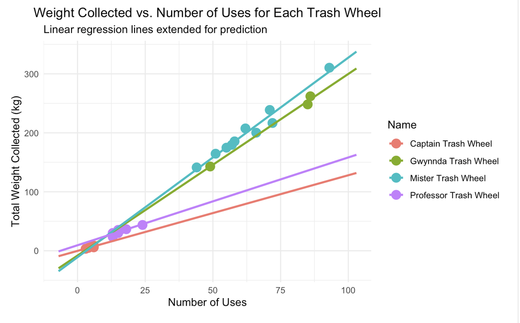

## Challenges Associated with the Dataset

Despite the value of this dataset, several issues warrant attention when interpreting its findings:

- **Completeness**: There are gaps in the dataset on days when the Trash Wheels were inactive due to maintenance or operational issues, which could skew analysis of long-term trends.
- **Accuracy**: The potential for human error in data entry and variations in the accuracy of measurement methods might affect the reliability of the data.
- **Consistency**: Over the years, modifications to data collection methodologies might have introduced inconsistencies that complicate comparisons over time.
- **Environmental Biases**: External factors such as weather conditions—particularly heavy rainfalls that can spike debris flow—need to be considered as they can significantly influence the volume of waste collected.

## Conclusion

In summary, the Trash Wheel project has proven to be an effective environmental safeguard for Baltimore’s waterways, successfully intercepting over one million pounds of debris and preventing it from polluting the Chesapeake Bay. Our analysis of the trashwheel.csv dataset highlights not only the types and quantities of collected waste but also reveals significant seasonal and event-driven fluctuations in waste accumulation. These findings underscore the importance of the Trash Wheels in urban waste management and environmental protection.

To build on these insights, further steps could include enhancing data collection methods to fill gaps and improve accuracy, and expanding public education campaigns to reduce littering and increase recycling efforts. Additionally, implementing more Trash Wheels at strategic locations could further decrease the pollutant load entering water bodies. Such initiatives would not only bolster the current project’s success but also align with LeadUp’s goals to cultivate leadership qualities among youth by encouraging proactive involvement in sustainable and community-focused actions.